# 第5章: 説明（観察データによる因果効果の推定）

Elena Llaudet & Kosuke Imai. Data Analysis for Social Science: A Friendly and Practical Introduction.

2026-03-09

# 5.1 観察研究と共変量

# 観察研究 (Observational Studies)

- 研究者が処置を無作為に割り当て**ない**研究。
- **メリット**: 倫理的・物理的な理由で実験できない現象も分析可能。
- **デメリット**: **共変量** (Confounders) によるバイアスが発生しやすい。

# 共変量 (Confounders)

- 処置 ($X$) と結果 ($Y$) の両方に影響を与える変数。
- これにより、処置群と統制群が「平均的に同一」ではなくなり、単純な平均の差では因果効果を測定できなくなる。

# 5.2 重回帰分析 (Multiple Regression)

# なぜ重回帰か？

- 単純な回帰 ($\hat{Y} = \hat{\alpha} + \hat{\beta} X$) では、他の要因を考慮できない。
- **重回帰**では、複数の独立変数を同時にモデルに含めることができる。
- 数式: $\hat{Y} = \hat{\alpha} + \hat{\beta}_1 X_1 + \hat{\beta}_2 X_2 + \dots$
- これにより、「$X_2$ などの**他の要因を一定に保ったまま**、$X_1$ が $Y$ に与える影響」を推定できる。

# 5.3 データの読み込みと準備

# ウクライナの選挙データ

- 2014年ウクライナ議会選挙のデータ。
- **関心**: ロシアのテレビ放送を視聴できることが、親ロシア派への投票に与える影響。

```r
# データの読み込み
precincts <- read.csv("UA_precincts.csv")
# 最初の数行を表示
head(precincts)
```

```
##   russian_tv pro_russian prior_pro_russian within_25km
## 1          0   2.7210884          25.14286           1
## 2          0   0.8928571          35.34483           0
## 3          1   1.6949153          20.53232           1
## 4          0  72.2689076          84.47761           1
## 5          0   1.2820513          28.99408           0
## 6          1   1.4285714          45.58824           0
```

# 5.4 共変量の制御

# ロシア放送の影響

- 単純に比較すると、ロシア放送を受信できる地域は、もともと親ロシア的な傾向が強い可能性がある（交絡）。
- そこで、**過去の投票率** (`prior_pro_russian`) を制御変数として追加する。

# ロシア放送の影響: Rコード

```r
# 重回帰モデルの推定
model_mult <- lm(pro_russian ~ russian_tv + prior_pro_russian,
                 data = precincts)
# 結果の表示
summary(model_mult)
```

```
##
## Call:
## lm(formula = pro_russian ~ russian_tv + prior_pro_russian, data = precincts)
##
## Residuals:
##     Min      1Q  Median      3Q     Max
## -38.776  -7.569   0.154   7.346  26.007
##
## Coefficients:
##                     Estimate Std. Error t value Pr(>|t|)
## (Intercept)       -13.795374   0.525786  -26.24   <2e-16 ***
## russian_tv          5.004216   0.484348   10.33   <2e-16 ***
## prior_pro_russian   0.767525   0.009919   77.38   <2e-16 ***
## ---
## Signif. codes:  0 '***' 0.001 '**' 0.01 '*' 0.05 '.' 0.1 ' ' 1
##
## Residual standard error: 11.01 on 3586 degrees of freedom
## Multiple R-squared:  0.6651, Adjusted R-squared:  0.6649
## F-statistic:  3561 on 2 and 3586 DF,  p-value: < 2.2e-16
```

# 推定値の解釈

- `russian_tv` の係数: 過去の投票率を一定に保ったとき、ロシア放送が受信可能であることで、今回の親ロシア派の得票率が平均で何%変化したか。

# 5.5 回帰モデルの比較

# モデル間の比較

- 制御変数を入れる前と後で係数がどう変わるかを確認する。

```r
# 単純回帰
model_sim <- lm(pro_russian ~ russian_tv, data = precincts)
coef(model_sim)["russian_tv"]
```

```
## russian_tv
##   15.64044
```

```r
# 重回帰（過去の投票率を制御）
coef(model_mult)["russian_tv"]
```

```
## russian_tv
##   5.004216
```

# 5.6 散布図と回帰平面（視覚化）

# 3次元的な関係の理解

- 複数の変数の関係をプロットする。

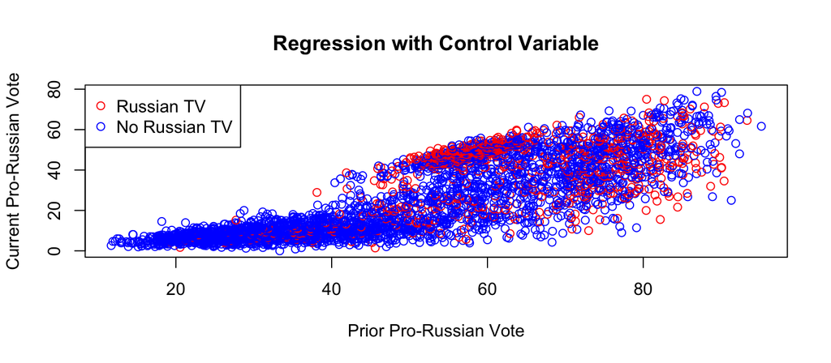

```r
# 高度な可視化の代わりに、制御変数ごとの回帰直線を確認（概念図）
plot(precincts$prior_pro_russian, precincts$pro_russian,
     col = ifelse(precincts$russian_tv == 1, "red", "blue"),
     xlab = "Prior Pro-Russian Vote", ylab = "Current Pro-Russian Vote",
     main = "Regression with Control Variable")
legend("topleft", legend = c("Russian TV", "No Russian TV"),
       col = c("red", "blue"), pch = 1)
```

# 5.7 まとめ

# 第5章のまとめ

- **観察研究**では、共変量（交絡因子）の存在を常に警戒する必要がある。
- **重回帰分析**を用いることで、他の要因を「一定に保つ（コントロールする）」ことができる。
- 適切な制御変数を含めることで、観察データからも、より信頼性の高い因果効果の推定が可能になる。
- ただし、**観察されていない共変量**によるバイアスの可能性は常に残る。